# Bulk 2 - apical-out-placental-organoids

Author

Giada Guntri

Published

2025-09-30

# Description

This script will generate the following plots and tables:

- Fig 4 a, b, c, d, e, f, g

- Supp Fig 3 a, b, c, d

- Supp Fig 4 a, b, c

- Supp Fig 5 b, c

- Supp Dat for Fig 4 c, d, e and Supp Fig 3 a, b, c, d

# Preparations

## load libraries

```r
library(ggplot2)
library(PCAtools)
library(edgeR)
library(ComplexHeatmap)
library(sva)
library(ggrepel)
library(dplyr)
```

## new folders

```r
plot_dir <- "Paper_Figures2"
if (!file.exists(plot_dir)) {
    dir.create(plot_dir, showWarnings = FALSE, recursive = FALSE)
}

table_dir <- "Paper_Tables2"
if (!file.exists(table_dir)) {
    dir.create(table_dir, showWarnings = FALSE, recursive = FALSE)
}
```

## loading all the data

```r
all_counts_orig <- read.delim("3797Fand3683F_raw_counts.uniqueID.20250919.tab", check.names=FALSE, stringsAsFactors=FALSE)

#Define symbol name of some genes of interest so they can be visualized in the volcano plots

all_counts_orig$SYMBOL[all_counts_orig$ENSEMBL == "ENSG00000171084"] <- "FAM86JP"

all_counts_orig$SYMBOL[all_counts_orig$ENSEMBL == "ENSG00000135248"] <- "FAM71F1"
```

## set up metadata

```r
# Get only the sample columns

sample_cols <- colnames(all_counts_orig)[6:ncol(all_counts_orig)]

metadata <- data.frame(
  sample = sample_cols,
  id = sub("^(s\\d+)_.*", "\\1", sample_cols),
  donor = sub("^s\\d+_(.*?)_.*_t\\d+$", "\\1", sample_cols),
  damaged = sub("^s\\d+_.*?_(.*?)_t\\d+$", "\\1", sample_cols),
  time = sub(".*_(t\\d+)$", "\\1", sample_cols),
  stringsAsFactors = FALSE
)


metadata$time.numeric <- as.numeric(sub("t", "", metadata$time))

metadata$time.char <- as.character(metadata$time.numeric)

metadata$time_damaged <- paste0(metadata$time, "_", metadata$damaged)

# Assign experiment numbers (first block = 3797, second block = 3683)
# first 21 samples are 3797, last 7 are 3683
metadata$experiment <- c(rep(3797, 21), rep(3683, 7))

metadata$donor_experiment <- paste0(metadata$donor, "_", metadata$experiment)

# View metadata
metadata
```

```
           sample  id donor damaged time time.numeric time.char time_damaged
1  s01_X113_nd_t0 s01  X113      nd   t0            0         0        t0_nd
2   s02_X113_d_t0 s02  X113       d   t0            0         0         t0_d
3   s03_X113_d_t6 s03  X113       d   t6            6         6         t6_d
4  s04_X113_d_t12 s04  X113       d  t12           12        12        t12_d
5  s05_X113_d_t24 s05  X113       d  t24           24        24        t24_d
6  s06_X113_d_t48 s06  X113       d  t48           48        48        t48_d
7  s07_X113_d_t72 s07  X113       d  t72           72        72        t72_d
8  s08_Y060_nd_t0 s08  Y060      nd   t0            0         0        t0_nd
9   s09_Y060_d_t0 s09  Y060       d   t0            0         0         t0_d
10  s10_Y060_d_t6 s10  Y060       d   t6            6         6         t6_d
11 s11_Y060_d_t12 s11  Y060       d  t12           12        12        t12_d
12 s12_Y060_d_t24 s12  Y060       d  t24           24        24        t24_d
13 s13_Y060_d_t48 s13  Y060       d  t48           48        48        t48_d
14 s14_Y060_d_t72 s14  Y060       d  t72           72        72        t72_d
```

[output cut: 43 more lines]

## exclude time point 72

in Y031

```r
counts_no72_Y031 <-cbind(all_counts_orig[,1:5 ],
                    all_counts_orig[,metadata$sample[metadata$sample != "s21_Y031_d_t72"]])

rownames(metadata) <- metadata$sample
metadata_no72_Y031 <- metadata[metadata$sample != "s21_Y031_d_t72", , drop = FALSE]
```

# PCA and Heatmap

## Batch correction by donor using ComBat-seq

```r
counts_no72_Y031.CBSeq_byD <- ComBat_seq(as.matrix(counts_no72_Y031[,-c(1:5)]), batch=metadata_no72_Y031$donor_experiment, group=NULL)
```

```
Found 4 batches
Using null model in ComBat-seq.
Adjusting for 0 covariate(s) or covariate level(s)
Estimating dispersions
Fitting the GLM model
Shrinkage off - using GLM estimates for parameters
Adjusting the data
```

```r
#add back the row names
rownames(counts_no72_Y031.CBSeq_byD) <- counts_no72_Y031$uniqueID
```

## PCA

Fig 4 a

PCA of batch corrected samples of the damage and regeneration timecourse, analysed by bulk RNA sequencing, coloured by time since damage (n=3 independent organoid lines).

```r
# Define custom colors for the groups
custom_colors <- c(t0_nd = 'grey60', t0_d = '#C49A00', t6_d = '#53B400', t12_d = '#00C094', t24_d = '#00B6EB', t48_d = '#A58AFF', t72_d = '#FB61D7')

counts_no72_Y031.bc.cpm.pca <- pca(cpm(counts_no72_Y031.CBSeq_byD, log=TRUE),
                              metadata = metadata_no72_Y031, removeVar = 0.1)
```

```
-- removing the lower 10% of variables based on variance
```

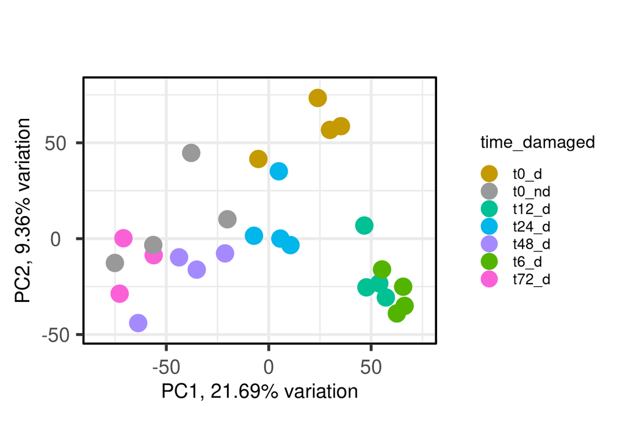

```r
metadata_no72_Y031$time_damaged <- as.factor(metadata_no72_Y031$time_damaged)

# Create the biplot with custom colors
PCA <- biplot(counts_no72_Y031.bc.cpm.pca,
       colby = 'time_damaged',
       colkey = custom_colors,
       pointSize = 5.5,
       lab = NULL,
       legendPosition = 'right')
# Remove the unnecessary fill label
PCA <- PCA + labs(fill = NULL)
print(PCA)
```

```r
tiff(paste0(plot_dir, "/Figure_4_a.tiff"), width = 9, height = 7, units = "in", res = 300)
print(PCA)
dev.off()
```

## Heatmap

Fig 4 b

Heatmap depicting batch corrected centered and scaled counts per million (cpm) of selected genes across the damage regeneration time course

### defining genes

```r
genes1 <- c("EGR1", "FOS", "JUN", "CCN2", "FOSB", "CCNG2", "MKI67", "PCNA",
            "CCNA2", "TP63", "IL4R", "IL6R", "TNFRSF12A", "THBS1", "PLAUR",
            "ARHGEF4", "CNN2", "LASP1", "GAL", "PTGES", "IL12RB2", "KRT17",
            "AXL", "IGFBP4", "TNFRSF21", "FOSL1", "IFI27", "TCL1B","OVOL1", "STRA6",
            "TWIST1", "PIK3AP1", "ENDOU", "GCM1", "MFSD2A", "CGA", "CGB3",
            "CYP19A1",  "SDC1", "INSL4", "PSG3", "PSG6", "ERVV-1", "ERVV-2",
            "ERVW-1", "ERV3-1", "CSH1, CSHL1", "KISS1", "FLT1", "IL31RA")

genes1
```

```
 [1] "EGR1"        "FOS"         "JUN"         "CCN2"        "FOSB"
 [6] "CCNG2"       "MKI67"       "PCNA"        "CCNA2"       "TP63"
[11] "IL4R"        "IL6R"        "TNFRSF12A"   "THBS1"       "PLAUR"
[16] "ARHGEF4"     "CNN2"        "LASP1"       "GAL"         "PTGES"
[21] "IL12RB2"     "KRT17"       "AXL"         "IGFBP4"      "TNFRSF21"
[26] "FOSL1"       "IFI27"       "TCL1B"       "OVOL1"       "STRA6"
[31] "TWIST1"      "PIK3AP1"     "ENDOU"       "GCM1"        "MFSD2A"
[36] "CGA"         "CGB3"        "CYP19A1"     "SDC1"        "INSL4"
[41] "PSG3"        "PSG6"        "ERVV-1"      "ERVV-2"      "ERVW-1"
[46] "ERV3-1"      "CSH1, CSHL1" "KISS1"       "FLT1"        "IL31RA"
```

### data to plot

#### assemble data in custom order

```r
# assemble data in custom order

new_samples <- c("s01_X113_nd_t0", "s02_X113_d_t0", "s03_X113_d_t6", "s04_X113_d_t12",
                 "s05_X113_d_t24", "s06_X113_d_t48", "s07_X113_d_t72", "s08_Y060_nd_t0",
                 "s09_Y060_d_t0", "s10_Y060_d_t6", "s11_Y060_d_t12", "s12_Y060_d_t24",
                 "s13_Y060_d_t48", "s14_Y060_d_t72", "s15_Y031_nd_t0", "s16_Y031_d_t0",
                 "s17_Y031_d_t6", "s18_Y031_d_t12", "s19_Y031_d_t24", "s20_Y031_d_t48",
                 "s22_X113_nd_t0", "s23_X113_d_t0", "s24_X113_d_t6", "s25_X113_d_t12",
                 "s26_X113_d_t24", "s27_X113_d_t48", "s28_X113_d_t72")

# Create the custom order without duplicates
custom_order <- unique(c(
  grep("nd_t0", new_samples, value = TRUE),
  grep("d_t0", new_samples, value = TRUE),
  grep("d_t6", new_samples, value = TRUE),
  grep("d_t12", new_samples, value = TRUE),
  grep("d_t24", new_samples, value = TRUE),
  grep("d_t48", new_samples, value = TRUE),
  grep("d_t72", new_samples, value = TRUE) ))

# Print the custom order to verify
print(custom_order)
```

```
 [1] "s01_X113_nd_t0" "s08_Y060_nd_t0" "s15_Y031_nd_t0" "s22_X113_nd_t0"
 [5] "s02_X113_d_t0"  "s09_Y060_d_t0"  "s16_Y031_d_t0"  "s23_X113_d_t0"
 [9] "s03_X113_d_t6"  "s10_Y060_d_t6"  "s17_Y031_d_t6"  "s24_X113_d_t6"
[13] "s04_X113_d_t12" "s11_Y060_d_t12" "s18_Y031_d_t12" "s25_X113_d_t12"
[17] "s05_X113_d_t24" "s12_Y060_d_t24" "s19_Y031_d_t24" "s26_X113_d_t24"
[21] "s06_X113_d_t48" "s13_Y060_d_t48" "s20_Y031_d_t48" "s27_X113_d_t48"
[25] "s07_X113_d_t72" "s14_Y060_d_t72" "s28_X113_d_t72"
```

#### calculate cpm values

```r
counts_no72_Y031.bc.cpm <- cpm(counts_no72_Y031.CBSeq_byD, log=FALSE)


data2plot1bc <- data.frame()

for (gene in unique(genes1)) {
  if (gene %in% rownames(counts_no72_Y031.bc.cpm)) {
    data2plot1bc <- rbind(data2plot1bc, counts_no72_Y031.bc.cpm[rownames
    (counts_no72_Y031.bc.cpm) == gene,])}
  }

rownames(data2plot1bc) <- unique(genes1[genes1 %in% rownames(counts_no72_Y031.bc.cpm)])

colnames(data2plot1bc) <- colnames(counts_no72_Y031.bc.cpm)

data2plot1bc.sc <- t(scale(t(data2plot1bc)))

# Reorder the columns in the data frame
data2plot1bc.sc <- data2plot1bc.sc[, custom_order]
```

### and plot

```r
# Create the heatmap with the custom order
plot1bc <- Heatmap(data2plot1bc.sc, cluster_columns = FALSE, cluster_rows = FALSE,
                   heatmap_legend_param = list(title = "cpm (c/s)", color_bar = "continuous"),
                   column_title = "Regeneration",
                   bottom_annotation = NULL)

# Display and save the heatmap
tiff(paste0(plot_dir, "/Figure_4_b.tiff"), width = 10, height = 12, units = "in", res = 300)

print(plot1bc)

dev.off()
```

# Differential gene expression analysis

## preparing the metadata

```r
donor = metadata_no72_Y031$donor
time = metadata_no72_Y031$time
damaged = metadata_no72_Y031$damaged
experiment = metadata_no72_Y031$experiment
donor3 = metadata_no72_Y031$donor_experiment
time3 = metadata_no72_Y031$time_damaged
```

## generate DGEList object

We work with the raw counts

```r
counts_no72_Y031.asDGEList <- DGEList(counts=counts_no72_Y031[,-c(1:5)],genes=counts_no72_Y031[,1:5]  )

rownames(counts_no72_Y031.asDGEList$counts) <- rownames(counts_no72_Y031.asDGEList$genes) <- counts_no72_Y031.asDGEList$genes$uniqueID
```

#### filter lowly expressed genes

```r
mincpm <- 1
minsamples <- 4

counts_no72_Y031.asDGEList.cpm <- cpm(counts_no72_Y031.asDGEList,  log = FALSE)


counts_no72_Y031.asDGEList <- counts_no72_Y031.asDGEList[ rowSums(counts_no72_Y031.asDGEList.cpm > mincpm) >= minsamples, , keep.lib.size=FALSE]
```

#### Normalization

```r
counts_no72_Y031.asDGEList <- calcNormFactors(counts_no72_Y031.asDGEList)   # same as normLibSizes(y)
head(counts_no72_Y031.asDGEList$samples)
```

```
               group lib.size norm.factors
s01_X113_nd_t0     1 25485051    0.8891809
s02_X113_d_t0      1 28269289    0.9973782
s03_X113_d_t6      1 29884973    0.9569127
s04_X113_d_t12     1 30138907    1.0046791
s05_X113_d_t24     1 27995530    1.0659919
s06_X113_d_t48     1 23297559    1.0290793
```

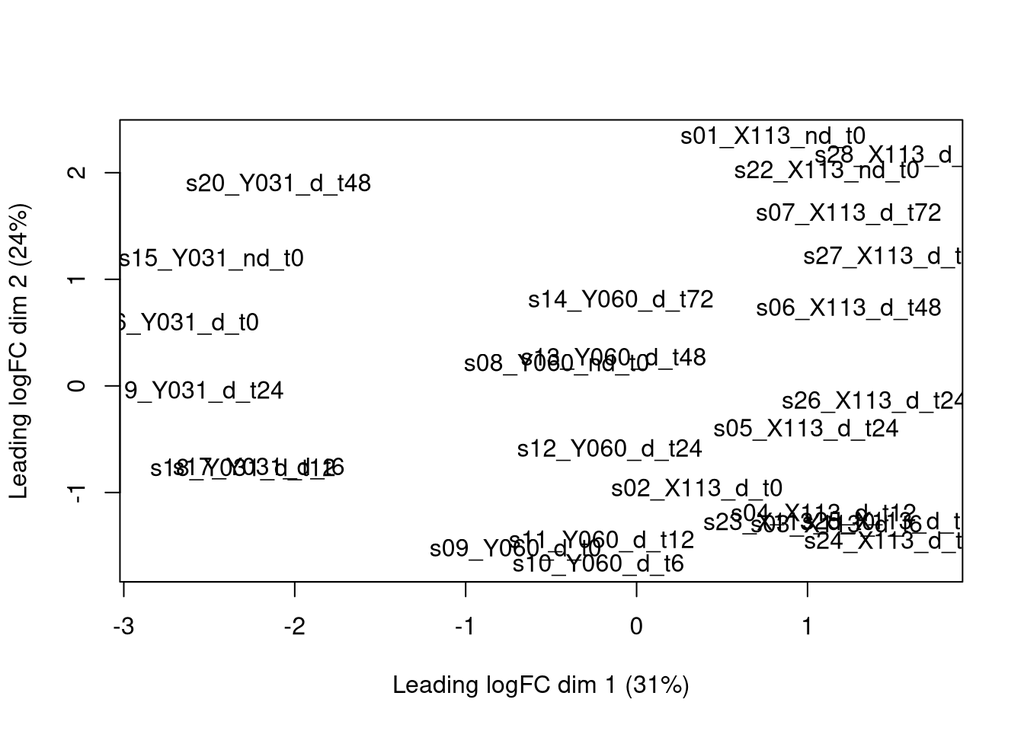

```r
plotMDS(counts_no72_Y031.asDGEList)
```

## Box plots

Figure 4 f, g, Supplemental Figure 4 a, b, and Supplemental Figure 5 b, c

```r
#| label: Fig 4 f, g Supp Fig 4 a, b, Supp Fig 5 b, c


# Define genes of interest
basal_list <- data.frame(gene = c("TNFSF12", "IL6R", "IL4R", "IL6", "TNFRSF12A", "THBS1", "IL4", "EPS8L1"))

# Define the desired timepoint order
time_order <- c("nd_t0", "d_t0", "d_t6", "d_t12", "d_t24", "d_t48", "d_t72")
custom_colors <- c(
  "nd_t0" = 'grey60',
  "d_t0" = '#C49A00',
  "d_t6" = '#53B400',
  "d_t12" = '#00C094',
  "d_t24" = '#00B6EB',
  "d_t48" = '#A58AFF',
  "d_t72" = '#FB61D7'
)

# Loop through each gene of interest
for (i in seq_len(nrow(basal_list))) {

  mygene <- basal_list$gene[i]

  # Check if gene exists in the expression matrix
  if (!(mygene %in% rownames(counts_no72_Y031.asDGEList.cpm))) {
    warning(paste("Gene", mygene, "not found in expression matrix. Skipping."))
    next
  }

  myENTREZ <- as.character(na.omit(all_counts_orig$uniqueID[all_counts_orig$SYMBOL == mygene]))
  expr.values <- counts_no72_Y031.asDGEList.cpm[mygene, ]

  df2plot <- data.frame(samples = colnames(counts_no72_Y031.asDGEList.cpm), cpm = expr.values)
  df2plot_withMetadata <- merge(df2plot, metadata_no72_Y031, by.x = "samples", by.y = 0, sort = FALSE)

  # Create a new column for time group from sample names
  df2plot_withMetadata$time_group <- gsub(".*_(nd|d)_t(\\d+)", "\\1_t\\2", df2plot_withMetadata$samples)
  df2plot_withMetadata$time_group <- factor(df2plot_withMetadata$time_group, levels = time_order)

  # Save plot as TIFF
  tiff(filename = paste0(plot_dir, "/", mygene, ".tiff"), width = 3200, height = 2400, res = 300)

p <- ggplot(df2plot_withMetadata, aes(x = time_group, y = cpm, fill = time_group)) +
    geom_boxplot(outlier.shape = NA, color = "black") +
    geom_jitter(aes(shape = donor3, fill = time_group),
                position = position_jitterdodge(jitter.width = 0.2, dodge.width = 0.6),
                size = 4, stroke = 1, color = "black") +
    scale_shape_manual(values = c(21, 22, 23, 24)) +
    scale_fill_manual(values = custom_colors) +
    labs(
      title = paste(myENTREZ, " ('", mygene, "')"),
      x = "Time Group", y = "CPM"
    ) +
    theme_bw(base_size = 15) +
    theme(axis.text.x = element_text(size = 13))

  print(p)
  dev.off()
}
```

## Setting up the design matrix

before damage

```r
t0_nd <- damaged== "nd" & time == "t0"
```

T0

```r
t0_d <- damaged== "d" & time == "t0"
```

T6

```r
t6_d <- damaged== "d" & time == "t6"
```

T12

```r
t12_d <- damaged== "d" & time == "t12"
```

T24

```r
t24_d <- damaged== "d" & time == "t24"
```

T48

```r
t48_d <- damaged== "d" & time == "t48"
```

T72

```r
t72_d <- damaged== "d" & time == "t72"
```

## Volcano plots where we compare to Before Damage

```r
design <- model.matrix(~donor3 + t0_d + t6_d + t12_d + t24_d + t48_d + t72_d)

rownames(design) <- colnames(counts_no72_Y031.asDGEList)
design
```

```
               (Intercept) donor3X113_3797 donor3Y031_3797 donor3Y060_3797
s01_X113_nd_t0           1               1               0               0
s02_X113_d_t0            1               1               0               0
s03_X113_d_t6            1               1               0               0
s04_X113_d_t12           1               1               0               0
s05_X113_d_t24           1               1               0               0
s06_X113_d_t48           1               1               0               0
s07_X113_d_t72           1               1               0               0
s08_Y060_nd_t0           1               0               0               1
s09_Y060_d_t0            1               0               0               1
s10_Y060_d_t6            1               0               0               1
s11_Y060_d_t12           1               0               0               1
s12_Y060_d_t24           1               0               0               1
s13_Y060_d_t48           1               0               0               1
s14_Y060_d_t72           1               0               0               1
s15_Y031_nd_t0           1               0               1               0
s16_Y031_d_t0            1               0               1               0
s17_Y031_d_t6            1               0               1               0
s18_Y031_d_t12           1               0               1               0
s19_Y031_d_t24           1               0               1               0
s20_Y031_d_t48           1               0               1               0
s22_X113_nd_t0           1               0               0               0
s23_X113_d_t0            1               0               0               0
s24_X113_d_t6            1               0               0               0
s25_X113_d_t12           1               0               0               0
s26_X113_d_t24           1               0               0               0
s27_X113_d_t48           1               0               0               0
s28_X113_d_t72           1               0               0               0
               t0_dTRUE t6_dTRUE t12_dTRUE t24_dTRUE t48_dTRUE t72_dTRUE
s01_X113_nd_t0        0        0         0         0         0         0
s02_X113_d_t0         1        0         0         0         0         0
s03_X113_d_t6         0        1         0         0         0         0
s04_X113_d_t12        0        0         1         0         0         0
s05_X113_d_t24        0        0         0         1         0         0
s06_X113_d_t48        0        0         0         0         1         0
s07_X113_d_t72        0        0         0         0         0         1
s08_Y060_nd_t0        0        0         0         0         0         0
s09_Y060_d_t0         1        0         0         0         0         0
s10_Y060_d_t6         0        1         0         0         0         0
s11_Y060_d_t12        0        0         1         0         0         0
```

[output cut: 24 more lines]

```

attr(,"contrasts")$t6_d
[1] "contr.treatment"

attr(,"contrasts")$t12_d
[1] "contr.treatment"

attr(,"contrasts")$t24_d
[1] "contr.treatment"

attr(,"contrasts")$t48_d
[1] "contr.treatment"

attr(,"contrasts")$t72_d
[1] "contr.treatment"
```

### Dispersion estimation

```r
counts_no72_Y031.asDGEList.disp <- estimateDisp(counts_no72_Y031.asDGEList, design, robust = TRUE)
counts_no72_Y031.asDGEList.disp$common.dispersion
```

```
[1] 0.03323518
```

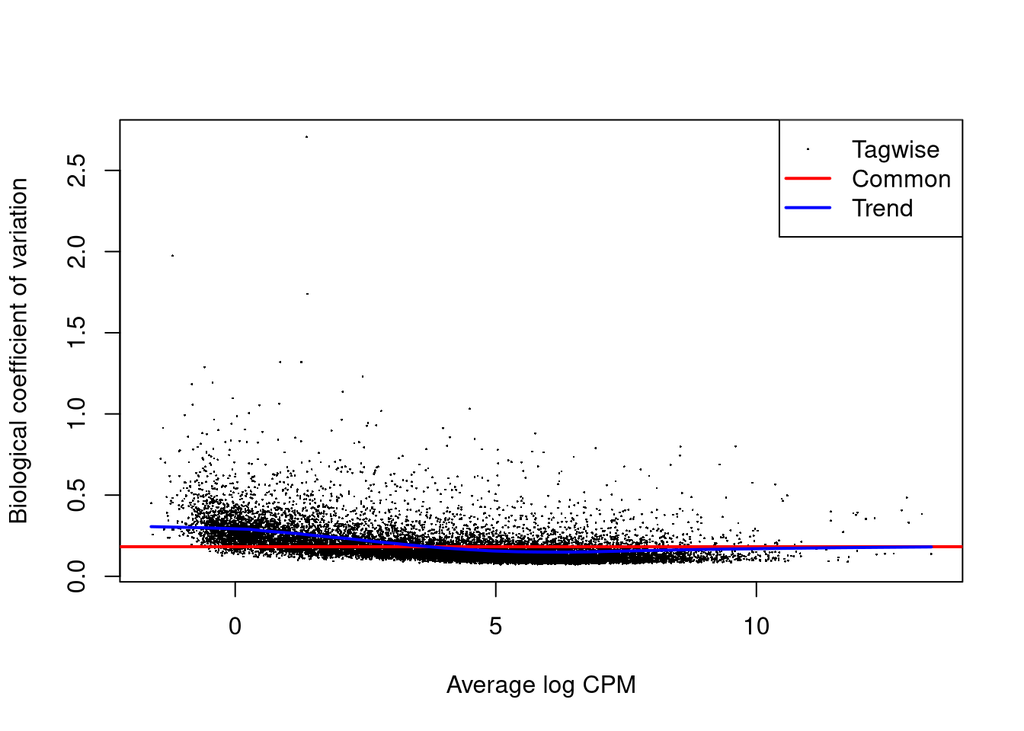

```r
plotBCV(counts_no72_Y031.asDGEList.disp)
```

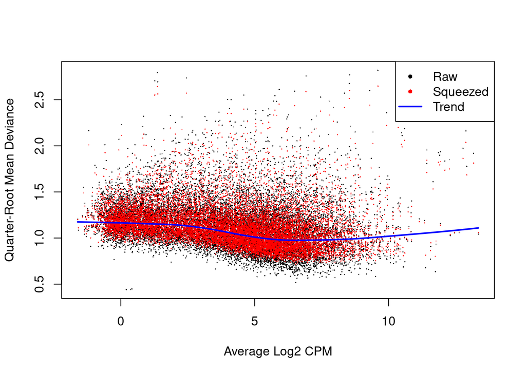

```r
fit <- glmQLFit(counts_no72_Y031.asDGEList.disp, design)

plotQLDisp(fit)
```

### Differential expression

#### Damage time 0 vs Before damage

Supplemental Figure 3 a, b and Supplemental Table S3

```r
qlf_1 <- glmQLFTest(fit, contrast=as.vector((colnames(design) == "t0_dTRUE") * +1 ))
topTags(qlf_1)
```

```
Coefficient:  1*t0_dTRUE
                             uniqueID         ENSEMBL    SYMBOL
EGR1                             EGR1 ENSG00000120738      EGR1
NA_ENSG00000226548 NA_ENSG00000226548 ENSG00000226548      <NA>
RELL2                           RELL2 ENSG00000164620     RELL2
SAXO3                           SAXO3 ENSG00000268655     SAXO3
HLF                               HLF ENSG00000108924       HLF
FOS                               FOS ENSG00000170345       FOS
STRA6                           STRA6 ENSG00000137868     STRA6
TRIM40                         TRIM40 ENSG00000204614    TRIM40
LINC02826                   LINC02826 ENSG00000275212 LINC02826
DENND2D                       DENND2D ENSG00000162777   DENND2D
                                                                GENENAME width
EGR1                                             early growth response 1  3137
NA_ENSG00000226548                                                  <NA>   652
RELL2                                                        RELT like 2  2583
SAXO3                              stabilizer of axonemal microtubules 3  1756
HLF                     HLF transcription factor, PAR bZIP family member  6776
FOS                Fos proto-oncogene, AP-1 transcription factor subunit  3186
STRA6                signaling receptor and transporter of retinol STRA6  7669
TRIM40                                    tripartite motif containing 40  2481
LINC02826                    long intergenic non-protein coding RNA 2826  4987
DENND2D                                        DENN domain containing 2D  6677
                       logFC     logCPM         F       PValue          FDR
EGR1                5.142583  4.3941363 239.91534 2.697204e-13 4.161516e-09
NA_ENSG00000226548 -4.395103 -1.2824154  80.93772 9.497625e-11 7.326943e-07
RELL2              -2.509778  3.6832369 123.17686 1.793748e-10 7.645946e-07
SAXO3              -5.095930  2.6623696 121.14196 1.982227e-10 7.645946e-07
HLF                -5.832040  0.7517075  81.32019 3.180416e-10 9.061706e-07
FOS                 5.243656  5.5149227 114.37556 3.587066e-10 9.061706e-07
STRA6              -3.852320  3.9994743 112.71173 4.111215e-10 9.061706e-07
TRIM40             -4.890588  0.8148066  78.02286 7.491228e-10 1.435938e-06
LINC02826          -3.751058 -0.2049629  88.39178 8.376072e-10 1.435938e-06
DENND2D            -2.616938  4.0860713  99.42297 1.297329e-09 1.933687e-06
```

```r
tt_1 <- as.data.frame(topTags(qlf_1,n=nrow(counts_no72_Y031.asDGEList)))

# Modify the status column based on logFC and FDR
tt_modified_1 <- tt_1 %>%
  mutate(status = factor(case_when(
    logFC > 2 & FDR < 0.05 ~ "up",
    logFC < (-2) & FDR < 0.05 ~ "down",
    TRUE ~ "ns"
  ), levels = c("up", "ns", "down")))


write.csv(tt_modified_1, file = paste0(table_dir, "/D0 vs BD.csv"), row.names = FALSE)

# Create the volcano plot with -log10(PValue) on the y-axis
vplot <- ggplot(tt_modified_1, aes(x = logFC, y = -log10(PValue), color = status)) +
  geom_point(size = 1) +
  scale_color_manual(values = c("firebrick", "grey", "dodgerblue")) +
  ggtitle("D0 vs ND0; logFC > |2|, logCPM > 1, PValue < 0.05") +
  theme(plot.title = element_text(size = 30, face = "bold.italic"),
        axis.title = element_text(size = 30, face = "bold"),
        axis.text = element_text(size = 30)) +
  guides(color = guide_legend(override.aes = list(size = 4))) +
  theme_bw() +
  geom_hline(yintercept = -log10(0.00660125146985328), linetype = "dashed", color = "black") +
  geom_vline(xintercept = 2, linetype = "dashed", color = "black") +
  geom_vline(xintercept = -2, linetype = "dashed", color = "black") +
  geom_label_repel(data = tt_modified_1 %>% filter(SYMBOL %in% c("EGR1", "FOS", "JUN", "FOSB", "CSHL1", "CGB1", "CGB5", "TCL1B", "SDC1", "PSG8", "CYP19A1", "TWIST1", "INSL4", "SLC26A1", "S100P", "CXCL11", "ENDOU", size = 7 )), aes(label = SYMBOL), size = 6,
                   box.padding = 0.5,
                   point.padding = 0.5,
                   max.overlaps = Inf,
                   segment.color = 'grey50'
  )



tiff(paste0(plot_dir, "/SuppFigure_3_b.tiff"), width = 10, height = 8, units = "in", res = 300)
print(vplot)
dev.off()
```

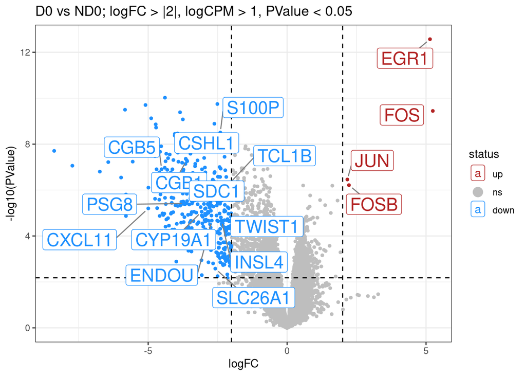

```r
# Display the plot
print(vplot)
```

#### Damage time 72 vs Before damage

Supplemental Figure 3 A and Supplemental Table S3

```r
qlf_7 <- glmQLFTest(fit,contrast=as.vector((colnames(design) == "t72_dTRUE") * +1) )

topTags(qlf_7)
```

```
Coefficient:  1*t72_dTRUE
                             uniqueID         ENSEMBL   SYMBOL
IFI27                           IFI27 ENSG00000165949    IFI27
LGALS3BP                     LGALS3BP ENSG00000108679 LGALS3BP
RASGRF2                       RASGRF2 ENSG00000113319  RASGRF2
NA_ENSG00000281162 NA_ENSG00000281162 ENSG00000281162     <NA>
IL2RG                           IL2RG ENSG00000147168    IL2RG
OAS1                             OAS1 ENSG00000089127     OAS1
UBE2L6                         UBE2L6 ENSG00000156587   UBE2L6
IRF7                             IRF7 ENSG00000185507     IRF7
MACC1                           MACC1 ENSG00000183742    MACC1
IRF9                             IRF9 ENSG00000213928     IRF9
                                                                     GENENAME
IFI27                                   interferon alpha inducible protein 27
LGALS3BP                                           galectin 3 binding protein
RASGRF2            Ras protein specific guanine nucleotide releasing factor 2
NA_ENSG00000281162                                                       <NA>
IL2RG                                    interleukin 2 receptor subunit gamma
OAS1                                        2'-5'-oligoadenylate synthetase 1
UBE2L6                                     ubiquitin conjugating enzyme E2 L6
IRF7                                           interferon regulatory factor 7
MACC1                                     MET transcriptional regulator MACC1
IRF9                                           interferon regulatory factor 9
                   width    logFC     logCPM         F       PValue
IFI27               4147 3.883071  3.9377419 118.53633 2.603077e-10
LGALS3BP            3422 1.130395  9.3639627  92.96225 2.375952e-09
RASGRF2            11032 3.220158 -0.5416004  66.29313 3.034044e-09
NA_ENSG00000281162  3841 4.340117  0.7212212  79.19628 3.794215e-09
IL2RG               2760 3.626660 -0.2358838  76.64289 3.976844e-09
OAS1               13021 3.055095  4.3745798  85.99418 4.756716e-09
UBE2L6              2062 2.287367  4.0041892  85.52752 4.992470e-09
IRF7                2612 1.761519  5.2323089  84.07466 5.802472e-09
MACC1               9898 1.629362  3.0846625  81.78322 7.427081e-09
IRF9                3582 1.427761  5.6429210  81.62655 7.519362e-09
                            FDR
IFI27              4.016287e-06
LGALS3BP           1.057294e-05
RASGRF2            1.057294e-05
NA_ENSG00000281162 1.057294e-05
IL2RG              1.057294e-05
OAS1               1.057294e-05
UBE2L6             1.057294e-05
IRF7               1.057294e-05
MACC1              1.057294e-05
IRF9               1.057294e-05
```

```r
tt_7 <- as.data.frame(topTags(qlf_7,n=nrow(counts_no72_Y031.asDGEList)))

# Modify the status column based on logFC and FDR
tt_modified_7 <- tt_7 %>%
  mutate(status = factor(case_when(
    logFC > 2 & FDR < 0.05 ~ "up",
    logFC < (-2) & FDR < 0.05 ~ "down",
    TRUE ~ "ns"
  ), levels = c("up", "ns", "down")))


write.csv(tt_modified_7, file = paste0(table_dir, "/D72 vs BD.csv"), row.names = FALSE)

# Create the volcano plot with -log10(PValue) on the y-axis
vplot <- ggplot(tt_modified_7, aes(x = logFC, y = -log10(PValue), color = status)) +
  geom_point(size = 1) +
  scale_color_manual(values = c("firebrick", "grey", "dodgerblue")) +
  ggtitle("ND0 vs D72; logFC > |2|, logCPM > 1, PValue < 0.05") +
    theme(plot.title = element_text(size = 30, face = "bold.italic"),
        axis.title = element_text(size = 30, face = "bold"),
        axis.text = element_text(size = 30)) +
  guides(color = guide_legend(override.aes = list(size = 4))) +
  theme_bw() +
  geom_hline(yintercept = -log10(0.00641132371289005), linetype = "dashed", color = "black") +
  geom_vline(xintercept = 2, linetype = "dashed", color = "black") +
  geom_vline(xintercept = -2, linetype = "dashed", color = "black") +
  geom_label_repel(data = tt_modified_7 %>% filter(SYMBOL %in% c("APOA2", "IFI27", "FAM86JP", "IGFBP3", "PALD1", "SPNS2", "FAM71F1",
                         "IL2RG", "RNF157", "PNCK", "PLAC8", "SLC6A8", "IFITM1", "SLCO4A1",
                         "IFIT1", "IL31RA", "XAF1", "PAPPA2", "VTCN1",
 size = 7)
), aes(label = SYMBOL), size = 6,
                   box.padding = 0.5,
                   point.padding = 0.5,
                   max.overlaps = Inf,
                   segment.color = 'grey50'
  )

# Save the plot
tiff(paste0(plot_dir, "/SuppFigure_3_a.tiff"), width = 10, height = 8, units = "in", res = 300)
print(vplot)
dev.off()
```

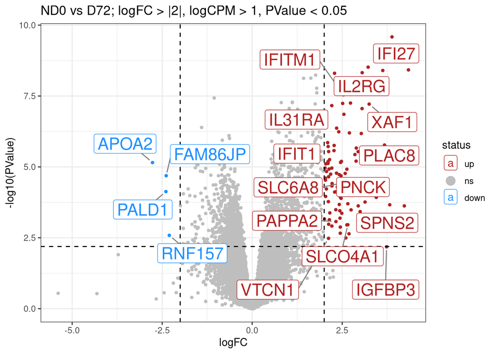

```r
# Display the plot
print(vplot)
```

## Volcano plots where we compare to Damage time 0

New model.matrix (do not include MG.21p.5)

```r
design <- model.matrix(~donor3 + t0_nd + t6_d + t12_d + t24_d + t48_d + t72_d)

rownames(design) <- colnames(counts_no72_Y031.asDGEList)
design
```

```
               (Intercept) donor3X113_3797 donor3Y031_3797 donor3Y060_3797
s01_X113_nd_t0           1               1               0               0
s02_X113_d_t0            1               1               0               0
s03_X113_d_t6            1               1               0               0
s04_X113_d_t12           1               1               0               0
s05_X113_d_t24           1               1               0               0
s06_X113_d_t48           1               1               0               0
s07_X113_d_t72           1               1               0               0
s08_Y060_nd_t0           1               0               0               1
s09_Y060_d_t0            1               0               0               1
s10_Y060_d_t6            1               0               0               1
s11_Y060_d_t12           1               0               0               1
s12_Y060_d_t24           1               0               0               1
s13_Y060_d_t48           1               0               0               1
s14_Y060_d_t72           1               0               0               1
s15_Y031_nd_t0           1               0               1               0
s16_Y031_d_t0            1               0               1               0
s17_Y031_d_t6            1               0               1               0
s18_Y031_d_t12           1               0               1               0
s19_Y031_d_t24           1               0               1               0
s20_Y031_d_t48           1               0               1               0
s22_X113_nd_t0           1               0               0               0
s23_X113_d_t0            1               0               0               0
s24_X113_d_t6            1               0               0               0
s25_X113_d_t12           1               0               0               0
s26_X113_d_t24           1               0               0               0
s27_X113_d_t48           1               0               0               0
s28_X113_d_t72           1               0               0               0
               t0_ndTRUE t6_dTRUE t12_dTRUE t24_dTRUE t48_dTRUE t72_dTRUE
s01_X113_nd_t0         1        0         0         0         0         0
s02_X113_d_t0          0        0         0         0         0         0
s03_X113_d_t6          0        1         0         0         0         0
s04_X113_d_t12         0        0         1         0         0         0
s05_X113_d_t24         0        0         0         1         0         0
s06_X113_d_t48         0        0         0         0         1         0
s07_X113_d_t72         0        0         0         0         0         1
s08_Y060_nd_t0         1        0         0         0         0         0
s09_Y060_d_t0          0        0         0         0         0         0
s10_Y060_d_t6          0        1         0         0         0         0
s11_Y060_d_t12         0        0         1         0         0         0
```

[output cut: 24 more lines]

```

attr(,"contrasts")$t6_d
[1] "contr.treatment"

attr(,"contrasts")$t12_d
[1] "contr.treatment"

attr(,"contrasts")$t24_d
[1] "contr.treatment"

attr(,"contrasts")$t48_d
[1] "contr.treatment"

attr(,"contrasts")$t72_d
[1] "contr.treatment"
```

### Dispersion estimation and fitting

```r
counts_no72_Y031.asDGEList.disp <- estimateDisp(counts_no72_Y031.asDGEList, design, robust = TRUE)
counts_no72_Y031.asDGEList.disp$common.dispersion
```

```
[1] 0.03323528
```

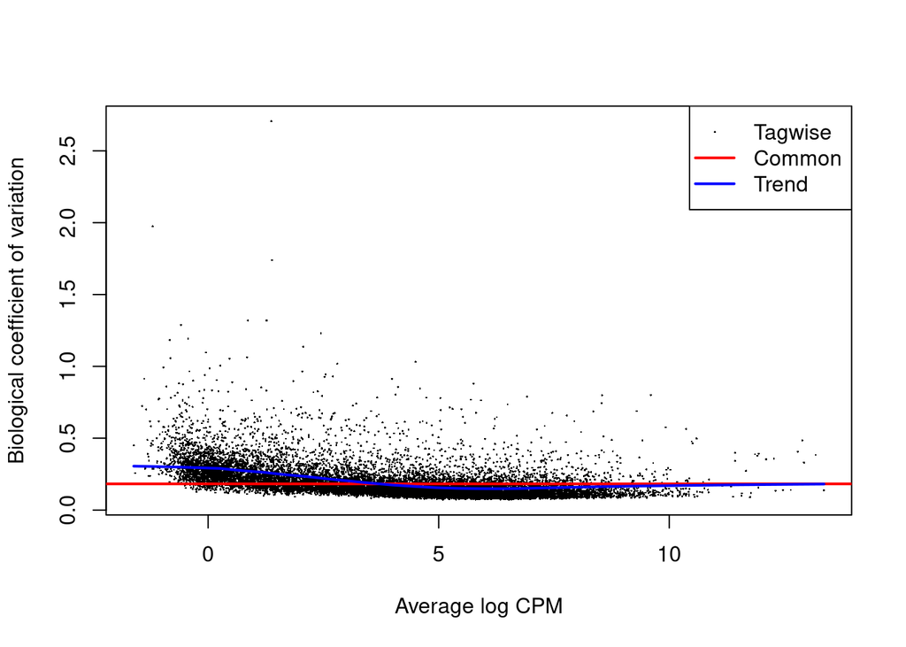

```r
plotBCV(counts_no72_Y031.asDGEList.disp)
```

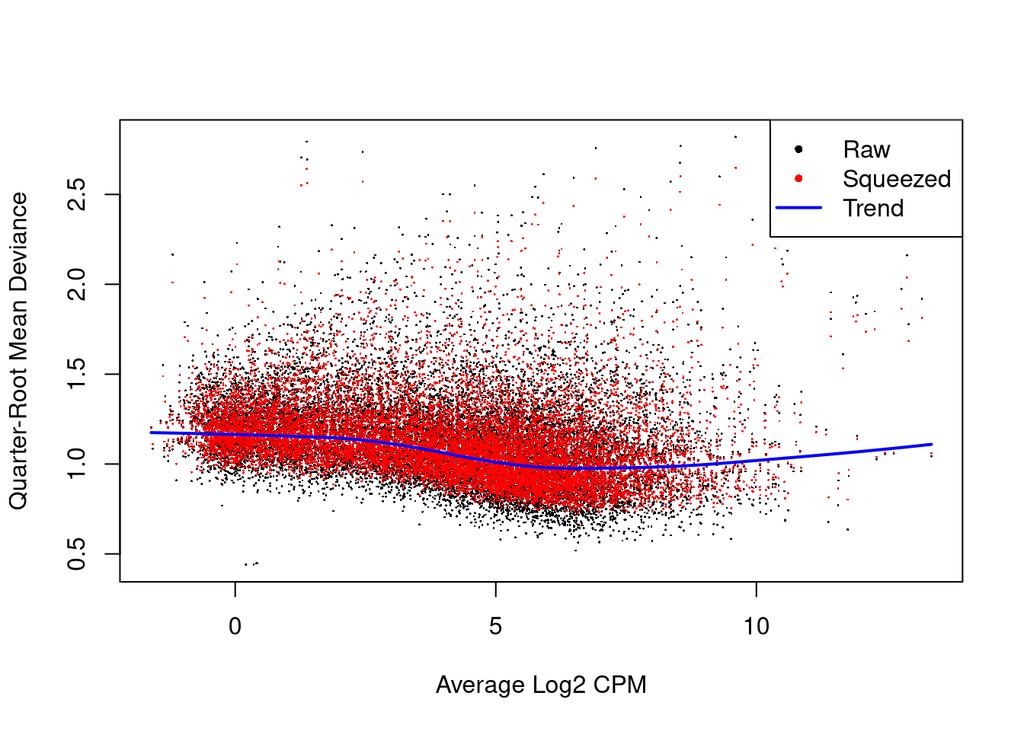

```r
fit <- glmQLFit(counts_no72_Y031.asDGEList.disp, design)

plotQLDisp(fit)
```

### Differential expression

#### Damage time 6 vs Damage time 0

Figure 4 D and Supplemental Table S3

```r
qlf_2 <- glmQLFTest(fit, contrast=as.vector((colnames(design) == "t6_dTRUE") * +1 ))
topTags(qlf_2)
```

```
Coefficient:  1*t6_dTRUE
         uniqueID         ENSEMBL   SYMBOL
KRT14       KRT14 ENSG00000186847    KRT14
ACTG2       ACTG2 ENSG00000163017    ACTG2
ABCG1       ABCG1 ENSG00000160179    ABCG1
SH3BGRL3 SH3BGRL3 ENSG00000142669 SH3BGRL3
TEF           TEF ENSG00000167074      TEF
KRT18       KRT18 ENSG00000111057    KRT18
EGR1         EGR1 ENSG00000120738     EGR1
IGFBP4     IGFBP4 ENSG00000141753   IGFBP4
GAL           GAL ENSG00000069482      GAL
EPS8         EPS8 ENSG00000151491     EPS8
                                                 GENENAME width     logFC
KRT14                                          keratin 14  2255  5.223696
ACTG2                        actin gamma 2, smooth muscle  3811  4.647019
ABCG1           ATP binding cassette subfamily G member 1  6121 -3.280322
SH3BGRL3 SH3 domain binding glutamate rich protein like 3   876  1.538224
TEF      TEF transcription factor, PAR bZIP family member  4702 -2.412286
KRT18                                          keratin 18  3069  1.674921
EGR1                              early growth response 1  3137 -4.988442
IGFBP4       insulin like growth factor binding protein 4  2205  2.363199
GAL                        galanin and GMAP prepropeptide  1300  4.948153
EPS8          EGFR pathway substrate 8, signaling adaptor  8540 -2.212203
             logCPM        F       PValue          FDR
KRT14     2.4940871 291.3230 8.280775e-15 1.277641e-10
ACTG2     0.2547326 176.1239 2.502911e-14 1.645703e-10
ABCG1     4.1047831 295.4724 3.199890e-14 1.645703e-10
SH3BGRL3  5.6238455 257.3230 1.305633e-13 5.036152e-10
TEF       3.8980948 247.2276 1.960884e-13 5.833051e-10
KRT18    11.5763640 242.9149 2.340554e-13 5.833051e-10
EGR1      4.3941363 239.9068 2.698150e-13 5.833051e-10
IGFBP4    3.3867821 233.1842 3.543061e-13 5.833051e-10
GAL       0.6881826 199.4672 3.608987e-13 5.833051e-10
EPS8      4.1069410 231.6560 3.780576e-13 5.833051e-10
```

```r
summary(decideTests(qlf_2))
```

```
       1*t6_dTRUE
Down         3073
NotSig       9128
Up           3228
```

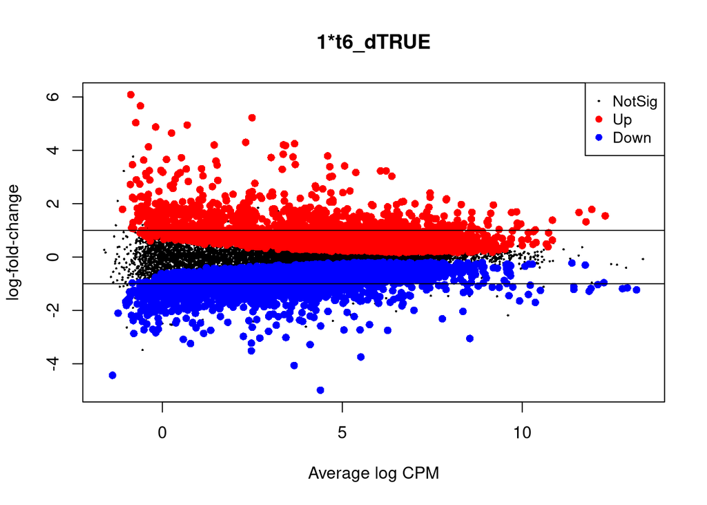

```r
plotMD(qlf_2)
abline(h=c(-1, 1), col="black")
```

```r
tt_2 <- as.data.frame(topTags(qlf_2,n=nrow(counts_no72_Y031.asDGEList)))


# Modify the status column based on logFC and FDR
tt_modified_2 <- tt_2 %>%
  mutate(status = factor(case_when(
    logFC > 2 & FDR < 0.05 ~ "up",
    logFC < (-2) & FDR < 0.05 ~ "down",
    TRUE ~ "ns"
  ), levels = c("up", "ns", "down")))

write.csv(tt_modified_2, file = paste0(table_dir, "/D6 vs D0.csv"), row.names = FALSE)

# Create the volcano plot with -log10(PValue) on the y-axis
vplot <- ggplot(tt_modified_2, aes(x = logFC, y = -log10(PValue), color = status)) +
  geom_point(size = 1) +
  scale_color_manual(values = c("firebrick", "grey", "dodgerblue")) +
  ggtitle("D0 versus T6; logFC > |2|, logCPM > 1, PValue < 0.05") +
    theme(plot.title = element_text(size = 30, face = "bold.italic"),
        axis.title = element_text(size = 30, face = "bold"),
        axis.text = element_text(size = 30)) +
  guides(color = guide_legend(override.aes = list(size = 4))) +
  theme_bw() +
  geom_hline(yintercept = -log10(0.0168406137075142), linetype = "dashed", color = "black") +
  geom_vline(xintercept = 2, linetype = "dashed", color = "black") +
  geom_vline(xintercept = -2, linetype = "dashed", color = "black") +
  geom_label_repel(data = tt_modified_2 %>% filter(SYMBOL %in% c("EGR1", "KRT14", "FOS", "SIRPB2", "VTN", "KRT17", "FIGNL2", "THBS1",
                         "CDKN2C", "IL12RB2", "CCNG2", "TSC22D3", "CD69", "ITGA2", "AXL",
                         "IL6", "PLAUR", "IGFBP4", "TNFRSF12A", "GPRC5A", "SOX12", "SPHK1", size = 7)
), aes(label = SYMBOL), size = 6,
                   box.padding = 0.5,
                   point.padding = 0.5,
                   max.overlaps = Inf,
                   segment.color = 'grey50'
  )

# Save the plot
tiff(paste0(plot_dir, "/Figure_4_d.tiff"), width = 10, height = 8, units = "in", res = 300)
print(vplot)
dev.off()
```

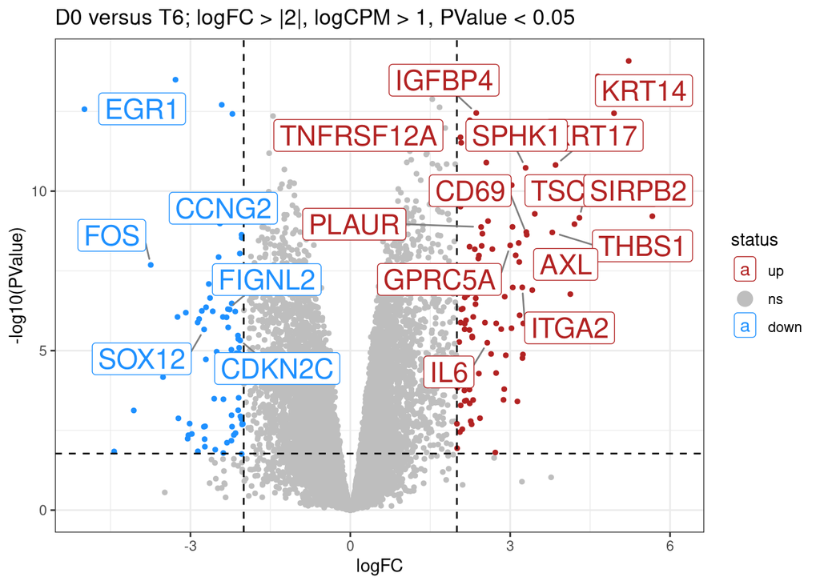

```r
# Display the plot
print(vplot)
```

#### Damage time 12 vs Damage time 0

Figure 4 E and Supplemental Table S3

```r
qlf_3 <- glmQLFTest(fit, contrast=as.vector((colnames(design) == "t12_dTRUE") * + 1 ))
topTags(qlf_3)
```

```
Coefficient:  1*t12_dTRUE
         uniqueID         ENSEMBL   SYMBOL
KRT14       KRT14 ENSG00000186847    KRT14
ACTG2       ACTG2 ENSG00000163017    ACTG2
ABCG1       ABCG1 ENSG00000160179    ABCG1
EGR1         EGR1 ENSG00000120738     EGR1
SH3BGRL3 SH3BGRL3 ENSG00000142669 SH3BGRL3
GAL           GAL ENSG00000069482      GAL
KRT18       KRT18 ENSG00000111057    KRT18
KRT18P28 KRT18P28 ENSG00000176855 KRT18P28
MYL9         MYL9 ENSG00000101335     MYL9
KRT17       KRT17 ENSG00000128422    KRT17
                                                 GENENAME width     logFC
KRT14                                          keratin 14  2255  5.416429
ACTG2                        actin gamma 2, smooth muscle  3811  4.530785
ABCG1           ATP binding cassette subfamily G member 1  6121 -2.972496
EGR1                              early growth response 1  3137 -4.784015
SH3BGRL3 SH3 domain binding glutamate rich protein like 3   876  1.409233
GAL                        galanin and GMAP prepropeptide  1300  4.748819
KRT18                                          keratin 18  3069  1.455885
KRT18P28                         keratin 18 pseudogene 28  1332  1.663284
MYL9                                 myosin light chain 9  2808  2.662612
KRT17                                          keratin 17  2996  3.865190
             logCPM        F       PValue          FDR
KRT14     2.4940871 321.2902 2.814270e-15 4.342137e-11
ACTG2     0.2547326 165.4614 5.704670e-14 4.400868e-10
ABCG1     4.1047831 262.8543 1.056261e-13 5.432348e-10
EGR1      4.3941363 227.2364 4.658933e-13 1.797067e-09
SH3BGRL3  5.6238455 217.4774 7.123644e-13 2.198214e-09
GAL       0.6881826 179.1671 1.145171e-12 2.944807e-09
KRT18    11.5763640 185.9521 3.380349e-12 7.245752e-09
KRT18P28  4.3140332 183.9796 3.756952e-12 7.245752e-09
MYL9      2.5702701 180.7543 4.700433e-12 8.058110e-09
KRT17     3.3583260 163.0627 1.279510e-11 1.974156e-08
```

```r
tt_3 <- as.data.frame(topTags(qlf_3,n=nrow(counts_no72_Y031.asDGEList)))


# Modify the status column based on logFC and FDR
tt_modified_3 <- tt_3 %>%
  mutate(status = factor(case_when(
    logFC > 2 & FDR < 0.05 ~ "up",
    logFC < (-2) & FDR < 0.05 ~ "down",
    TRUE ~ "ns"
  ), levels = c("up", "ns", "down")))


write.csv(tt_modified_3, file = paste0(table_dir, "/D12 vs D0.csv"), row.names = FALSE)

# Create the volcano plot with -log10(PValue) on the y-axis
vplot <- ggplot(tt_modified_3, aes(x = logFC, y = -log10(PValue), color = status)) +
  geom_point(size = 1) +
  scale_color_manual(values = c("firebrick", "grey", "dodgerblue")) +
  ggtitle("D12 vs D0; logFC > |2|, logCPM > 1, PValue < 0.05") +
    theme(plot.title = element_text(size = 30, face = "bold.italic"),
        axis.title = element_text(size = 30, face = "bold"),
        axis.text = element_text(size = 30)) +
  guides(color = guide_legend(override.aes = list(size = 4))) +
  theme_bw() +
  geom_hline(yintercept = -log10(0.0165027508617822), linetype = "dashed", color = "black") +
  geom_vline(xintercept = 2, linetype = "dashed", color = "black") +
  geom_vline(xintercept = -2, linetype = "dashed", color = "black") +
  geom_label_repel(data = tt_modified_3 %>% filter(SYMBOL %in%  c("EGR1", "KRT14", "FOS", "THBS1", "FOSB", "GPRC5A", "CDKN2C", "ITGA2",
 "VTN", "IL12RB2", "GH2", "KRT17", "SIRPB2", "AXL", "IL1R2", "ITGA1",
 "CYP1A1", "NOG", "SPRR3", "FGF1", "RBP4", size = 7)
), aes(label = SYMBOL), size = 6,
                   box.padding = 0.5,
                   point.padding = 0.5,
                   max.overlaps = Inf,
                   segment.color = 'grey50'
  )

# Save the plot
tiff(paste0(plot_dir, "/Figure_4_e.tiff"), width = 10, height = 8, units = "in", res = 300)
print(vplot)
dev.off()
```

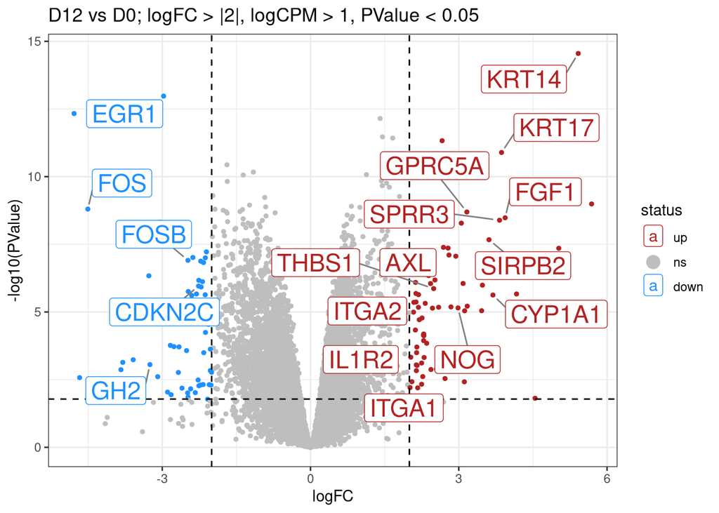

```r
# Display the plot
print(vplot)
```

#### Damage time 24 vs Damage time 0

Supplemental Figure 3 C and Supplemental Table S3

```r
qlf_4 <- glmQLFTest(fit, contrast=as.vector((colnames(design) == "t24_dTRUE") * + 1 ))
topTags(qlf_4)
```

```
Coefficient:  1*t24_dTRUE
         uniqueID         ENSEMBL   SYMBOL
EGR1         EGR1 ENSG00000120738     EGR1
KRT14       KRT14 ENSG00000186847    KRT14
CNTNAP2   CNTNAP2 ENSG00000174469  CNTNAP2
SH3BGRL3 SH3BGRL3 ENSG00000142669 SH3BGRL3
FOS           FOS ENSG00000170345      FOS
KRT18       KRT18 ENSG00000111057    KRT18
LY6G6C     LY6G6C ENSG00000204421   LY6G6C
COCH         COCH ENSG00000100473     COCH
NUP210     NUP210 ENSG00000132182   NUP210
ADGRF4     ADGRF4 ENSG00000153294   ADGRF4
                                                      GENENAME width     logFC
EGR1                                   early growth response 1  3137 -4.605650
KRT14                                               keratin 14  2255  3.750123
CNTNAP2                         contactin associated protein 2 16377 -1.052092
SH3BGRL3      SH3 domain binding glutamate rich protein like 3   876  0.921864
FOS      Fos proto-oncogene, AP-1 transcription factor subunit  3186 -4.446887
KRT18                                               keratin 18  3069  1.001849
LY6G6C                  lymphocyte antigen 6 family member G6C  1004  1.876645
COCH                                                   cochlin  4031 -1.018632
NUP210                                         nucleoporin 210  8195 -1.065508
ADGRF4                  adhesion G protein-coupled receptor F4  3391  1.537657
            logCPM         F       PValue          FDR
EGR1      4.394136 218.80296 6.807604e-13 1.050345e-08
KRT14     2.494087 132.35696 3.528444e-11 2.722018e-07
CNTNAP2   3.857893  96.60831 1.681356e-09 6.842553e-06
SH3BGRL3  5.623846  94.08163 2.133884e-09 6.842553e-06
FOS       5.514923  93.69739 2.217432e-09 6.842553e-06
KRT18    11.576364  89.92360 3.197999e-09 8.223655e-06
LY6G6C    4.628625  85.62358 4.940603e-09 1.088980e-05
COCH      4.139702  83.03941 6.471188e-09 1.248049e-05
NUP210    6.776589  80.44196 8.543301e-09 1.328187e-05
ADGRF4    4.679769  80.37409 8.608378e-09 1.328187e-05
```

```r
tt_4 <- as.data.frame(topTags(qlf_4,n=nrow(counts_no72_Y031.asDGEList)))

# Modify the status column based on logFC and FDR
tt_modified_4 <- tt_4 %>%
  mutate(status = factor(case_when(
    logFC > 2 & FDR < 0.05 ~ "up",
    logFC < (-2) & FDR < 0.05 ~ "down",
    TRUE ~ "ns"
  ), levels = c("up", "ns", "down")))

write.csv(tt_modified_4, file = paste0(table_dir, "/D24 vs D0.csv"), row.names = FALSE)

# Create the volcano plot with -log10(PValue) on the y-axis
vplot <- ggplot(tt_modified_4, aes(x = logFC, y = -log10(PValue), color = status)) +
  geom_point(size = 1) +
  scale_color_manual(values = c("firebrick", "grey", "dodgerblue")) +
  ggtitle("D24 vs D0; logFC > |2|, logCPM > 1, PValue < 0.05") +
    theme(plot.title = element_text(size = 30, face = "bold.italic"),
        axis.title = element_text(size = 30, face = "bold"),
        axis.text = element_text(size = 30)) +
  guides(color = guide_legend(override.aes = list(size = 4))) +
  theme_bw() +
  geom_hline(yintercept = -log10(0.006211311), linetype = "dashed", color = "black") +
  geom_vline(xintercept = 2, linetype = "dashed", color = "black") +
  geom_vline(xintercept = -2, linetype = "dashed", color = "black") +
  geom_label_repel(data = tt_modified_4 %>% filter(SYMBOL %in%  c("EGR1", "KRT14", "FOS", "CYP1A1", "VTN", "ITGA1", "FOSB", "IFI27",
"JUN", "KRT17", "GPRC5A", "TCL1B", "STRA6", "ALPP", "DHRS9",
"PIK3AP1", "ALPG", size = 7 )), aes(label = SYMBOL), size = 6,
                   box.padding = 0.5,
                   point.padding = 0.5,
                   max.overlaps = Inf,
                   segment.color = 'grey50'
  )



# Save the plot
tiff(paste0(plot_dir, "/SuppFigure_3_c.tiff"), width = 10, height = 8, units = "in", res = 300)
print(vplot)
dev.off()
```

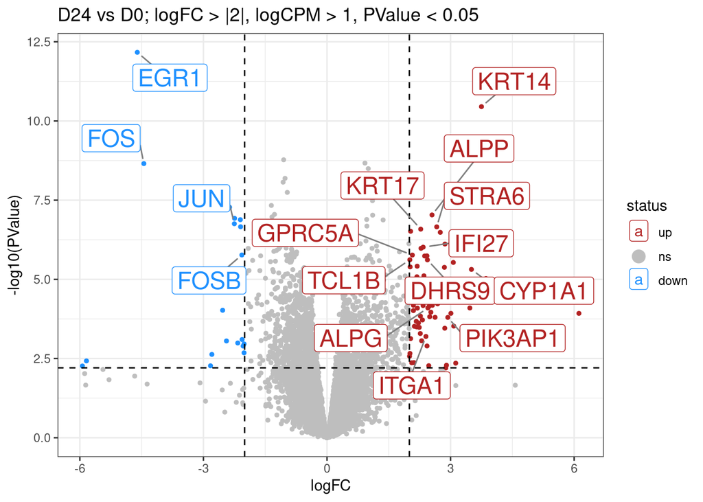

```r
# Display the plot
print(vplot)
```

#### Damage time 48 vs Damage time 0

Supplemental Figure 3 D and Supplemental Table S3

```r
qlf_5 <- glmQLFTest(fit, contrast=as.vector((colnames(design) == "t48_dTRUE") * + 1 ))
topTags(qlf_5)
```

```
Coefficient:  1*t48_dTRUE
         uniqueID         ENSEMBL   SYMBOL
EGR1         EGR1 ENSG00000120738     EGR1
LY6G6C     LY6G6C ENSG00000204421   LY6G6C
KRT18P28 KRT18P28 ENSG00000176855 KRT18P28
KRT18       KRT18 ENSG00000111057    KRT18
STON2       STON2 ENSG00000140022    STON2
STRA6       STRA6 ENSG00000137868    STRA6
KRT8         KRT8 ENSG00000170421     KRT8
KRT8P3     KRT8P3 ENSG00000254285   KRT8P3
DENND2D   DENND2D ENSG00000162777  DENND2D
IFI27       IFI27 ENSG00000165949    IFI27
                                                    GENENAME width     logFC
EGR1                                 early growth response 1  3137 -4.969451
LY6G6C                lymphocyte antigen 6 family member G6C  1004  2.049278
KRT18P28                            keratin 18 pseudogene 28  1332  1.215114
KRT18                                             keratin 18  3069  1.038926
STON2                                               stonin 2  7812  1.670609
STRA6    signaling receptor and transporter of retinol STRA6  7669  3.499292
KRT8                                               keratin 8  6881  1.212054
KRT8P3                                keratin 8 pseudogene 3  1449  1.243398
DENND2D                            DENN domain containing 2D  6677  2.463470
IFI27                  interferon alpha inducible protein 27  4147  3.219778
            logCPM         F       PValue          FDR
EGR1      4.394136 239.19882 2.779799e-13 4.288951e-09
LY6G6C    4.628625 101.28705 1.094837e-09 5.074062e-06
KRT18P28  4.314033  96.99085 1.622185e-09 5.074062e-06
KRT18    11.576364  96.54701 1.690310e-09 5.074062e-06
STON2     3.630555  95.35351 1.892013e-09 5.074062e-06
STRA6     3.999474  94.92627 1.973191e-09 5.074062e-06
KRT8     12.305824  90.97108 2.884020e-09 5.871636e-06
KRT8P3    7.830007  89.23155 3.425812e-09 5.871636e-06
DENND2D   4.086071  88.76332 3.593599e-09 5.871636e-06
IFI27     3.937742  87.57919 4.090165e-09 5.871636e-06
```

```r
tt_5 <- as.data.frame(topTags(qlf_5,n=nrow(counts_no72_Y031.asDGEList)))


# Modify the status column based on logFC and FDR
tt_modified_5 <- tt_5 %>%
  mutate(status = factor(case_when(
    logFC > 2 & FDR < 0.05 ~ "up",
    logFC < (-2) & FDR < 0.05 ~ "down",
    TRUE ~ "ns"
  ), levels = c("up", "ns", "down")))


write.csv(tt_modified_5, file = paste0(table_dir, "/D48 vs D0.csv"), row.names = FALSE)

# Create the volcano plot with -log10(PValue) on the y-axis
vplot <- ggplot(tt_modified_5, aes(x = logFC, y = -log10(PValue), color = status)) +
  geom_point(size = 1) +
  scale_color_manual(values = c("firebrick", "grey", "dodgerblue")) +
  ggtitle("D48 vs D0; logFC > |2|, logCPM > 1, PValue < 0.05") +
    theme(plot.title = element_text(size = 30, face = "bold.italic"),
        axis.title = element_text(size = 30, face = "bold"),
        axis.text = element_text(size = 30)) +
  guides(color = guide_legend(override.aes = list(size = 4))) +
  theme_bw() +
  geom_hline(yintercept = -log10(0.011593291980048), linetype = "dashed", color = "black") +
  geom_vline(xintercept = 2, linetype = "dashed", color = "black") +
  geom_vline(xintercept = -2, linetype = "dashed", color = "black") +
  geom_label_repel(data = tt_modified_5 %>% filter(SYMBOL %in% c("EGR1", "FOS", "JUN","CP", "TCL1B", "PSG9", "S100P", "SLC1A2", "CGB5", "MFSD2A", "ENDOU", "PSG4"  , size = 7, max.overlaps = Inf)
), aes(label = SYMBOL), size = 6,
                   box.padding = 0.5,
                   point.padding = 0.5,
                   max.overlaps = Inf,
                   segment.color = 'grey50'
  )

# Save the plot
tiff(paste0(plot_dir, "/SuppFigure_3_d.tiff"), width = 10, height = 8, units = "in", res = 300)
print(vplot)
dev.off()
```

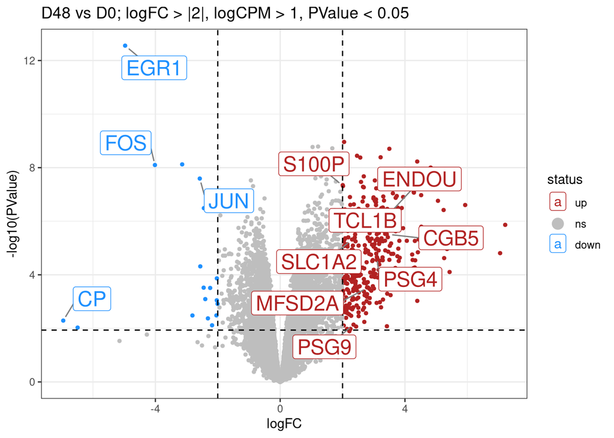

```r
# Display the plot
print(vplot)
```

```r
getwd()
```

```
[1] "/home_fmi/01/guntgiad/bulk/Paper Ida September 25"
```

#### Damage time 72 vs Damage time 0

Figure 4 C and Supplemental Table S3

```r
qlf_6 <- glmQLFTest(fit, contrast=as.vector((colnames(design) == "t72_dTRUE") * + 1 ))
topTags(qlf_6)
```

```
Coefficient:  1*t72_dTRUE
                             uniqueID         ENSEMBL    SYMBOL
RPL3L                           RPL3L ENSG00000140986     RPL3L
NA_ENSG00000185168 NA_ENSG00000185168 ENSG00000185168      <NA>
EGR1                             EGR1 ENSG00000120738      EGR1
TRIM40                         TRIM40 ENSG00000204614    TRIM40
FAM151AP1                   FAM151AP1 ENSG00000234805 FAM151AP1
SAXO3                           SAXO3 ENSG00000268655     SAXO3
LINC00323                   LINC00323 ENSG00000226496 LINC00323
IFI27                           IFI27 ENSG00000165949     IFI27
RELL2                           RELL2 ENSG00000164620     RELL2
KRT18                           KRT18 ENSG00000111057     KRT18
                                                                  GENENAME
RPL3L                                            ribosomal protein L3 like
NA_ENSG00000185168                                                    <NA>
EGR1                                               early growth response 1
TRIM40                                      tripartite motif containing 40
FAM151AP1          family with sequence similarity 151 member A pseudogene
SAXO3                                stabilizer of axonemal microtubules 3
LINC00323                       long intergenic non-protein coding RNA 323
IFI27                                interferon alpha inducible protein 27
RELL2                                                          RELT like 2
KRT18                                                           keratin 18
                   width     logFC     logCPM        F       PValue
RPL3L               2758  5.381689  0.1003221 148.8563 4.673115e-13
NA_ENSG00000185168  2197  3.090039  3.0956283 187.1961 3.173814e-12
EGR1                3137 -4.675817  4.3941363 180.3857 4.624429e-12
TRIM40              2481  5.733331  0.8148068 104.5578 2.676885e-11
FAM151AP1           1834  4.605642 -0.8761085 100.8750 4.059221e-11
SAXO3               1756  5.630414  2.6623697 141.5011 4.527373e-11
LINC00323           2570  5.874413  1.1181861 100.7162 4.576769e-11
IFI27               4147  4.218354  3.9377420 138.4323 6.027101e-11
RELL2               2583  2.773328  3.6832369 134.3317 7.910318e-11
KRT18               3069  1.291306 11.5763640 129.0317 1.157114e-10
                            FDR
RPL3L              7.210149e-09
NA_ENSG00000185168 2.378344e-08
EGR1               2.378344e-08
TRIM40             1.008785e-07
FAM151AP1          1.008785e-07
SAXO3              1.008785e-07
LINC00323          1.008785e-07
IFI27              1.162402e-07
RELL2              1.356092e-07
KRT18              1.785311e-07
```

```r
tt_6 <- as.data.frame(topTags(qlf_6,n=nrow(counts_no72_Y031.asDGEList)))



# Modify the status column based on logFC and FDR
tt_modified_6 <- tt_6 %>%
  mutate(status = factor(case_when(
    logFC > 2 & FDR < 0.05 ~ "up",
    logFC < (-2) & FDR < 0.05 ~ "down",
    TRUE ~ "ns"
  ), levels = c("up", "ns", "down")))


write.csv(tt_modified_6, file = paste0(table_dir, "/D72 vs D0.csv"), row.names = FALSE)


# Create the volcano plot with -log10(PValue) on the y-axis
vplot <- ggplot(tt_modified_6, aes(x = logFC, y = -log10(PValue), color = status)) +
  geom_point(size = 1) +
  scale_color_manual(values = c("firebrick", "grey", "dodgerblue")) +
  ggtitle("D72 vs D0; logFC > |2|, logCPM > 1, PValue < 0.05") +
    theme(plot.title = element_text(size = 30, face = "bold.italic"),
        axis.title = element_text(size = 30, face = "bold"),
        axis.text = element_text(size = 30)) +
  guides(color = guide_legend(override.aes = list(size = 4))) +
  theme_bw() +
  geom_hline(yintercept = -log10(0.0176007843532707), linetype = "dashed", color = "black") +
  geom_vline(xintercept = 2, linetype = "dashed", color = "black") +
  geom_vline(xintercept = -2, linetype = "dashed", color = "black") +
  geom_label_repel(data = tt_modified_6 %>% filter(SYMBOL %in% c("EGR1","FOS", "JUN", "CP", "FAM20A", "CCN2", "LGR5", "SLC2A11", "EPS8L1", "TCL1B", "CXCL11", "CYP11A1", "GPRC5A", "ERVW-1", "CGB5", "SDC1", "PSG7", "CGB3", "ENDOU","CYP19A1", size = 7 ) ), aes(label = SYMBOL), size = 6,
                   box.padding = 0.5,
                   point.padding = 0.5,
                   max.overlaps = Inf,
                   segment.color = 'grey50'
  )

# Save the plot
tiff(paste0(plot_dir, "/Figure_4_c.tiff"), width = 10, height = 8, units = "in", res = 300)
print(vplot)
dev.off()
```

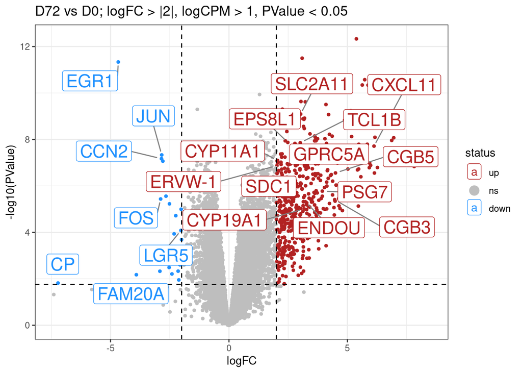

```r
# Display the plot
print(vplot)
```